# CODE Appendix

```python
def big_cutting(higgs,qcd,low_bound, high_bound, feature):
    higgs_cut = cutting(higgscut_dict, low_bound, high_bound,feature)
    qcd_cut = cutting(qcdcut_dict, low_bound, high_bound,feature)
    higgs_yield = len(higgs_cut)/len(higgs_dict)  * 50
    qcd_yield  = len(qcd_cut)/len(qcd_dict)  * 2000
    print(higgs_yield)
    print(qcd_yield)
    print("The expected significance is: ", higgs_yield/np.sqrt(qcd_yield))
```

```python
def cut_helper(data,low_bound,high_bound,original):
    x_val = (data['mass'] > low_bound) & (data['mass'] < high_bound)
    y_val = data[x_val]
    ratio = len(y_val)/len(data)
    output = original * ratio
    return output
```

```python
def cutting(data,low_bound, high_bound, feature):
    x_val = (data > low_bound) & (data< high_bound)
    y_val = data[x_val]
    return y_val
```

```python
def mass_cut(if_high):
    if if_high:
        high_mass_cut = all_cutting(high[:, 3], 121, 129)
        plt.hist(qcd_cut['mass'], 300, density=True, label='qcd')
        plt.hist(higgs_cut['mass'], 300, density=True, label='higgs')
        plt.hist(high_mass_cut, 300, density=True, alpha = 0.3, label='high mass without cut', color = 'grey')
        plt.title("high mass with cut")
        plt.ylabel("probability")
        plt.xlabel("mass")

    else:
        low_mass_cut = all_cutting(low[:, 3], 121, 129)
        plt.hist(qcd_cut['mass'], 300, density=True, label='qcd')
        plt.hist(higgs_cut['mass'], 300, density=True, label='higgs')
        plt.hist(low_mass_cut, 300, density=True, alpha = 0.3, label='low mass without cut', color = 'grey')
        plt.title("mass without cut")
        plt.ylabel("probability")
        plt.xlabel("Mass")

        plt.legend()
        plt.show()
```

```python
def plot_mass(if_high):
    if if_high:
        plt.hist(highLumi['mass'], 300, density=True, label="high  Data")
    else:
        plt.hist(lowLumi['mass'], 300, density=True, label="low Data")

    plt.yscale('log')
    plt.hist(higgs_dict['mass'], 100, density=True, alpha=0.3, label="higgs", color = 'blue')
    plt.hist(qcd_dict['mass'], 100, density=True, alpha=0.3, label="qcd", color = 'cyan')
    plt.title("mass without cut")
    plt.legend()
    plt.show()
```

```python
def plot_d2(if_high):
    plt.hist(qcd_dict['d2'], 300, density=True, label='qcd')
    plt.hist(higgs_dict['d2'], 300, density=True, label='higgs')
    if if_high:
        plt.hist(high[:6], 300, density=True, alpha = 0.3, label='high d2 without cut')
    else:
        plt.hist(low[:6], 300, density=True, alpha = 0.3, label='low d2 without cut')

    plt.title("D2 without cut")
    plt.ylabel("probability")
    plt.ylim(0, 0.4)
    plt.xlabel("D2")
    plt.xlim(0,50)
    plt.legend()
    plt.show()
```

```python
def plot_ee2(if_high):
    plt.hist(qcd_dict['ee2'], 300, density=True, label='qcd')
    plt.hist(higgs_dict['ee2'], 300, density=True, label='higgs')
    if if_high:
        plt.hist(high[:,4], 300, density=True, alpha = 0.3, label='high ee2 without cut')
    else:
        plt.hist(low[:,4], 300, density=True, alpha = 0.3, label='low ee2 without cut')

    plt.title("ee2 with  cut")
    plt.ylabel("Probability")
    plt.ylim(0, 35)
    plt.xlabel("EE2")
    plt.xlim(0,0.2)
    plt.legend()
    plt.show()
```

```python
def d2_cut(if_high):
    plt.hist(qcd_dict['d2'], 300, density=True, label='qcd')
    plt.hist(higgs_dict['d2'], 300, density=True, label='higgs')
    if if_high:
        high_d2_cut = all_cutting(high[:, 6], 0, 11)
        plt.hist(high_d2_cut, 300, density=True, alpha = 0.4, label='high d2 with cut')
    else:
        low_d2_cut = all_cutting(low[:, 6], 0, 11)
        plt.hist(low_d2_cut, 300, density=True, alpha = 0.4, label='low d2 with cut')

    plt.title("D2 with Cut")
    plt.ylabel("Probability")
    plt.xlabel("D2")
    plt.xlim(0,70)
    plt.legend()
    plt.show()
```

```python
def ee2_cut(if_high):
    plt.hist(qcd_dict['ee2'], 300, density=True, label='QCD')
    plt.hist(higgs_dict['ee2'], 300, density=True, label='Higgs')
    if if_high:
        high_ee2_cut = all_cutting(high[:, 4], 0, 5)
        plt.hist(high_ee2_cut, 300, density=True, alpha = 0.4, label='high ee2 with cut')
    else:
        low_ee2_cut = all_cutting(low[:, 4], 0, 5)
        plt.hist(low_ee2_cut, 300, density=True, alpha = 0.4, label='low ee2 with cut')

    plt.title("ee2 with Cut")
    plt.ylabel("Probability")
    plt.xlabel("ee2")
    plt.legend()
    plt.show()
```

```python
# this cutting method is for lab 8, since it is similar to the  cutting method above
# I put this cutting method here for covenience
def all_cutting(data,low_bound, high_bound):
    x_val = (data > low_bound) & (data < high_bound)
    y_val = data[x_val]
    return y_val
```

# LAB7 & 8

Event selection optimization You and your lab partner should pick different pT (transverse momentum) samples (one uses low-pT sampels and the other use high-pT samples) for this lab. In each pT sample, there are dedicated training samples for event selection optimization. All studies should be carried out by normalizing Higgs and QCD samples in each pT sample to given expected yields accordingly (See Dataset descriptions).

```python
from scipy import stats
import pickle
import statistics
import pandas as pd
import numpy as np
import seaborn
import matplotlib.pyplot as plt
import pickle
import h5py
#this sets the size of the plot to something useful
plt.rcParams["figure.figsize"] = (5,4) # TODO: change the size to figure later, it's too small
```

First, using the starter code from previous provided in the specification to import the data set.

```python
# open the file of interest, and use pickle loading
higgs = open ("higgs_100000_pt_1000_1200.pkl",'rb')
higgs_dict = pickle.load(higgs)
qcd = open("qcd_100000_pt_1000_1200.pkl",'rb')
qcd_dict = pickle.load(qcd)
higgs_dict.keys()
# list all keys of the files
higgs_dict.keys()
```

```
Index(['pt', 'eta', 'phi', 'mass', 'ee2', 'ee3', 'd2', 'angularity', 't1',
       't2', 't3', 't21', 't32', 'KtDeltaR'],
      dtype='object')
```

```python
# Print two variables, mass and d2, of the first 10 jets
for i in range(10):
 print(higgs_dict['mass'][i],higgs_dict['d2'][i])
```

```
126.39070494296645 1.565920565144541
125.73547207947769 0.8224079853829884
125.94694825108256 1.1595192989207739
133.47505458091868 1.1312895177410458
135.04731904755826 5.084334868566442
126.18831893079289 1.9893365548544923
132.22698108959537 0.8322677007024063
125.91413826896284 2.2895005833240227
125.00446344009822 0.8944416286773573
135.17626897095028 1.0176201623059749
```

some information about the data set given in the spec:  
high PT: Sample_pt_1000_1200  
Training sample and normalization  
higgs_100000_pt_1000_1200.pkl (Expected yields Nhiggs=50 )  
qcd_100000_pt_1000_1200.pkl (Expected yields Nqcd=2000 )  
Pseudo-experiments  
data_highLumi_pt_1000_1200.h5  
data_lowLumi_pt_1000_1200.h5

# Question 1

Make a stacked histogram plot for the feature variable: mass  
Evaluate expected significance without any event selection.  
Use Poisson statistics for significance calculation  
Compare your number of NHiggs/(√NQCD) . If they are equivalent, explain your findings.

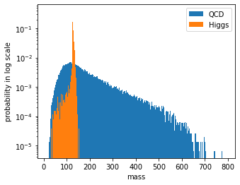

```python
# first make the histoggram for the mass
hist_qcd = plt.hist(qcd_dict.mass, density=True, bins=500, label='QCD')
hist_higgs = plt.hist(higgs_dict.mass, density=True, bins=500, label='Higgs')
plt.ylabel('probability in log scale')
plt.xlabel('mass')
plt.yscale("log")
plt.legend()
plt.show()
```

```python
# significance without any event selection
n_higgs = 50 # from the cell above
n_qcd = 2000 #from the cell above
higgs_mean = np.mean(higgs_dict)['mass']
qcd_mean  = np.mean(qcd_dict)['mass']
sum_n_higgs_qcd = n_higgs + n_qcd
print(higgs_mean)
```

```
126.66383222477353
```

```python
signif_1 = stats.norm.ppf(stats.poisson.cdf(sum_n_higgs_qcd, n_qcd))
print(signif_1)
```

```
1.1282230087754428
```

```python
signif_2 = n_higgs/np.sqrt(n_qcd)
print(signif_2)
```

```
1.118033988749895
```

```python
diff = abs(signif_2 - signif_1)
print(diff)
```

```
0.01018902002554789
```

Since the difference is around 0.01, I would say that they are the same numerically. However, they have some difference conceptually. When the poisson distribution has a large parameter $\lambda$, it can be approximated by Gaussian with parameters,$\lambda$ and sqrt( $\lambda$), since the sum equals n_higgs + n_qcd, the formula for the significance are the same.

# Question 2

Identify mass cuts to optimize the expected significance.  
Try different mass cuts systematically  
Evaluate expeced significance for each set of mass cuts  
Identify the set of the mass cuts which give you the highest significance.

Since we are required to Try different mass cuts systematically, I write a for loop to accomplish this.

```python
for i in range(1,20):
    # in order to prevent my computer from over-heat, I choose the step to be 1.25
    # and the loop number is 20, we can change it simply if we want by changing the parameters
    # do it in a symmetrical way
    step = 1.25
    hig_temp = cut_helper(higgs_dict,100+(i-1)*1.25,150-(i-1)*1.25,50)
    qcd_temp = cut_helper(qcd_dict,100+(i-1)*1.25,150-(i-1)*1.25,2000)
    print("Trial:",i,"Higgs value:",hig_temp, ",qcd value:",qcd_temp,"expected significance of cut",i,"is :",hig_temp/np.sqrt(qcd_temp))
    i = i + 1
```

```
Trial: 1 Higgs value: 49.025999999999996 ,qcd value: 626.22 expected significance of cut 1 is : 1.9591288224692132
Trial: 2 Higgs value: 48.9855 ,qcd value: 598.48 expected significance of cut 2 is : 2.002362597586396
Trial: 3 Higgs value: 48.9495 ,qcd value: 570.16 expected significance of cut 3 is : 2.049981241914713
Trial: 4 Higgs value: 48.9065 ,qcd value: 541.46 expected significance of cut 4 is : 2.1017613148737624
Trial: 5 Higgs value: 48.848 ,qcd value: 511.92 expected significance of cut 5 is : 2.1589656787453366
Trial: 6 Higgs value: 48.7715 ,qcd value: 481.28 expected significance of cut 6 is : 2.223142010262364
Trial: 7 Higgs value: 48.6605 ,qcd value: 452.54 expected significance of cut 7 is : 2.2874314126366024
Trial: 8 Higgs value: 48.5095 ,qcd value: 421.70000000000005 expected significance of cut 8 is : 2.362245322735425
Trial: 9 Higgs value: 48.327 ,qcd value: 390.26 expected significance of cut 9 is : 2.446317466358408
Trial: 10 Higgs value: 48.0755 ,qcd value: 357.8 expected significance of cut 10 is : 2.541579164877917
Trial: 11 Higgs value: 47.735 ,qcd value: 326.04 expected significance of cut 11 is : 2.643634949211767
Trial: 12 Higgs value: 47.191 ,qcd value: 294.98 expected significance of cut 12 is : 2.747659388286989
Trial: 13 Higgs value: 46.265499999999996 ,qcd value: 261.58 expected significance of cut 13 is : 2.860585891209941
Trial: 14 Higgs value: 44.812999999999995 ,qcd value: 228.11999999999998 expected significance of cut 14 is : 2.9670327304803847
Trial: 15 Higgs value: 42.7765 ,qcd value: 194.86 expected significance of cut 15 is : 3.0643890255343313
Trial: 16 Higgs value: 40.506 ,qcd value: 159.92000000000002 expected significance of cut 16 is : 3.20308134302659
Trial: 17 Higgs value: 37.914500000000004 ,qcd value: 128.28 expected significance of cut 17 is : 3.3475406344693024
Trial: 18 Higgs value: 33.8165 ,qcd value: 96.18 expected significance of cut 18 is : 3.448150950983038
Trial: 19 Higgs value: 27.3195 ,qcd value: 63.839999999999996 expected significance of cut 19 is : 3.419214192345823
```

```python
lower = 100 +(18-1) * 1.25
upper = 150 - (18-1) * 1.25
print(lower)
print(upper)
```

```
121.25
128.75
```

The highest expected significance is given by the cut 18. The expected significance is around 3.44.

# Question 3

Make stacked histogram plots for the reset of features  
Set A of plots without any event selection  
Can you identify another feature as discriminative as mass feature (i.e. equal or better significance after feature cut)  
Set B of plots with your optimal mass cuts  
Can you identify additional feature to further imrpove expected signifiance?

```python
qcdcut =  (qcd_dict['mass'] <129) & (qcd_dict['mass'] >121)
qcdcut_dict = qcd_dict[qcdcut]
higgscut = (higgs_dict['mass'] <129) & (higgs_dict['mass'] >121)
higgscut_dict = higgs_dict[higgscut]
names = higgs_dict.keys()
```

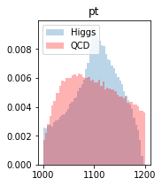

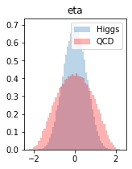

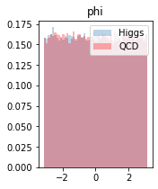

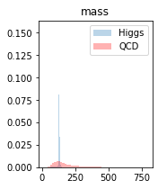

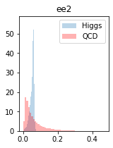

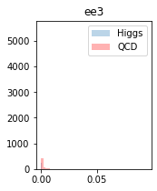

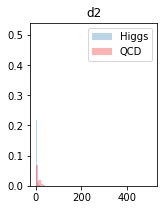

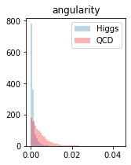

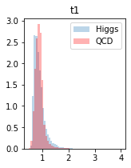

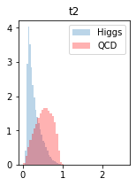

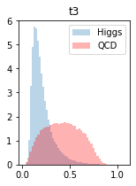

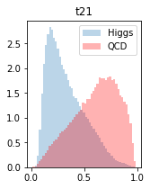

[1 more figures not shown]

```python
# here is the regular
for i in range(13):
    name = names[i]
    plt.figure(figsize=(5,3))
    plt.subplot(1,2,1)
    plt.title(name)
    #plt.yscale('log')
    plt.hist(higgs_dict[name],50, alpha = 0.3,label = 'Higgs',density = 'true')
    plt.hist(qcd_dict[name],50,alpha = 0.3,color='r', label = 'QCD',density = 'ture')
    plt.legend()
```

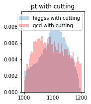

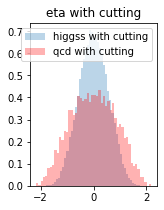

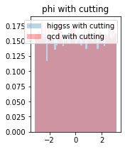

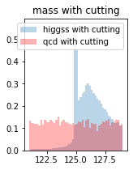

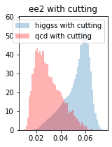

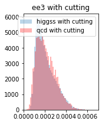

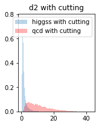

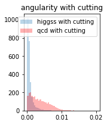

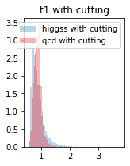

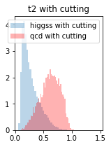

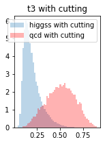

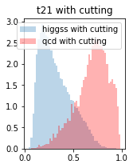

[1 more figures not shown]

```python
# here is the plots after cutting
for i in range(13):
    name = names[i]
    plt.figure(figsize=(5,3))
    plt.subplot(1,2,1)
    #plt.yscale('log')
    plt.title(name + " with cutting")
    plt.hist(higgscut_dict[name],50, alpha = 0.3,label = 'higgss with cutting',density = 'true')
    plt.hist(qcdcut_dict[name],50,alpha = 0.3,color='r', label = 'qcd with cutting',density = 'ture')
    plt.legend()
```

For the plots above, we can see that there is a large discrepency for ee2, d2 mass, and maybe ee3(I cannot really see it clearly). Let's explore each one of them.

# Question 4

Optimize event selections using multiple features (if necessary)  
Find a set of feature cuts which can help you to achieve the best significance.  
Compare significance (before/after event selection) dervied in your pT samples to your lab partner. Describe your findings.

I don't know if it is neccessary or not. So I will test few features to see who it works

```python
# from x-axis in the graph above
big_cutting(higgs_dict, qcd_dict,0,11,'d2')
```

```
34.8155
102.56
The expected significance is:  3.4378239320496053
```

```python
# from x-axis in the graph above
big_cutting(higgs_dict, qcd_dict,0,5,'ee2')
```

```
34.8155
102.56
The expected significance is:  3.4378239320496053
```

```python
# from x-axis in the graph above
big_cutting(higgs_dict, qcd_dict,121,129,'mass')
```

```
34.8155
102.56
The expected significance is:  3.4378239320496053
```

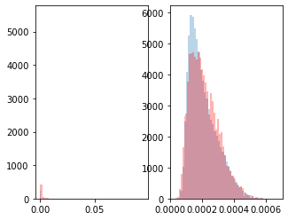

```python
plt.subplot(1,2,1)
plt.hist(higgs_dict['ee3'],50, alpha = 0.3,label = 'Higgs',density = 'true')
plt.hist(qcd_dict['ee3'],50,alpha = 0.3,color='r', label = 'qcd',density = 'ture')
plt.subplot(1,2,2)
plt.hist(higgscut_dict['ee3'],50, alpha = 0.3,label = 'higgss with cutting',density = 'true')
plt.hist(qcdcut_dict['ee3'],50,alpha = 0.3,color='r', label = 'qcd with cutting',density = 'ture')
```

seems like ee3 don't need a cut

# Question 5

Bonus (optional):  
Plot 2-dimensional scattering plots between top two most discriminative features  
Can you find a curve or a linear combination in this 2D plane which gives even better sensitivity? Extended reading: Lab 7 is a classificaition problem using multi-dimensional features in supervised machine learning. We can use popular machine learning tools to develop an optimial classifier which can maximize information by using all features. For interested students, you can read https://scikit-learn.org/stable/supervised_learning.html

```python
# useless testing program
# TODO: delete this
def q5_helper():
    print()
```

[output not shown]

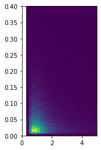

```python
# d2 and ee2, d2 and mass, mass and ee 2
# I think d2 and ee2 has the largest difference
plt.subplot(1,2,1)
plt.hist2d(higgs_dict['d2'], qcd_dict['ee2'], bins =[300,300])
plt.xlim(0,5)
plt.ylim(0,0.4)
```

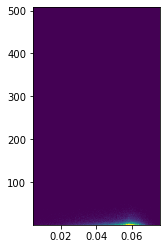

```python
plt.subplot(1,2,2)
plt.xlim(0.01,0.07)
plt.ylim(0,50)
plt.hist2d(higgs_dict['ee2'], qcd_dict['d2'], bins=[300,300])
plt.show()
```

# Lab 8

Pseudo-experiment data analysis Using your optimized event selection, hunt for your signal by using one of the pseduo-experiment dataset.  
For each task below, you will choose one of the observed data from your specific pT sample to perform the analysis.

Read the data set first

I will use the mass cut to do this part of the experiment.

```python
highLumi = pd.read_hdf('data_highLumi_pt_1000_1200.h5')
high = highLumi.to_numpy()
lowLumi = pd.read_hdf('data_lowLumi_pt_1000_1200.h5')
low = lowLumi.to_numpy()
highLumi.keys()
```

```
Index(['pt', 'eta', 'phi', 'mass', 'ee2', 'ee3', 'd2', 'angularity', 't1',
       't2', 't3', 't21', 't32', 'KtDeltaR'],
      dtype='object')
```

```python
higgs_cut = all_cutting(higgs_dict, 121, 129)
qcd_cut = all_cutting(qcd_dict, 121, 129)
```

# Question 1 & 2

High luminosity data  
Focus on each feature of your event selection.  
Plot observed data, overlap with expected signal and background (normalized to observed yields) without event selection.  
Plot observed data, overlap with expected signal and background (normalized to observed yields) with optimal event selection.  
Evaluate observed significance and compare your results to expectation  
Low luminosity data  
Focus on each feature of your event selection.  
Plot observed data, overlap with expected signal and background (normalized to observed yields) without event selection.  
Plot observed data, overlap with expected signal and background (normalized to observed yields) with optimal event selection.  
Evaluate observed significance and compare your results to expectation

# First I will plot all of them high and low without cut

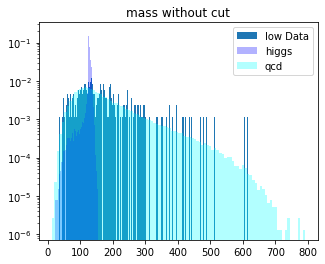

```python
plot_mass(False)
```

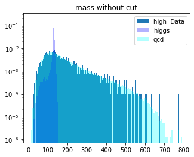

```python
plot_mass(True)
```

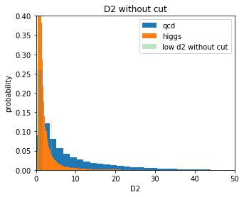

```python
plot_d2(False)
```

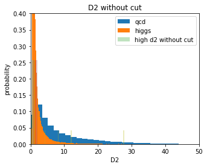

```python
plot_d2(True)
```

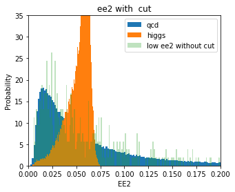

```python
plot_ee2(False)
```

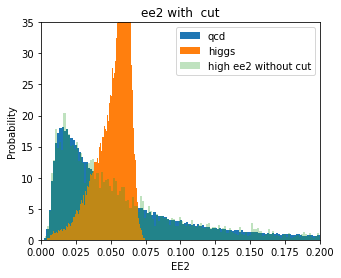

```python
plot_ee2(True)
```

# Here is all the plots that WITH CUT

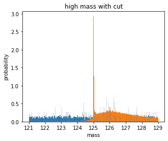

```python
mass_cut(True)
```

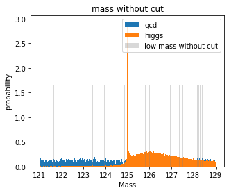

```python
mass_cut(False)
```

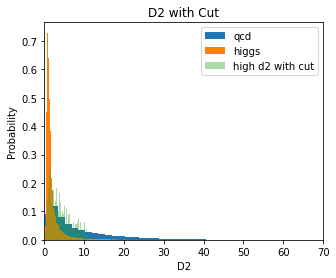

```python
d2_cut(True)
```

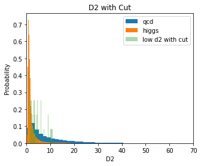

```python
d2_cut(False)
```

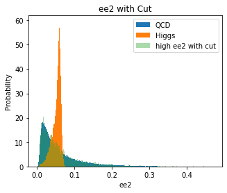

```python
ee2_cut(True)
```

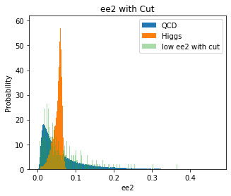

```python
ee2_cut(False)
```

# Question 3

95% Confidence Level of signal yields  
In the low luminosity data, the observed significance is less than 5 σ . We will calculate the 95% confidence level upper limit of signal yield.  
Evaluate the expected 95% confidence level upper limit  
Evaluate the observed 95% confidence level upper limit  
Compare expectation to observation. Comment on your finding.

```python
temp1 = np.percentile(higgs_dict, 95)
print('expected upper', temp1)
temp2 = np.percentile(qcd_dict, 95)
print('observed upper', temp2)
temp3 = np.percentile(lowLumi, 95)
print('low lumin:', temp3)
```

```
expected upper 1080.4221976970337
observed upper 1063.4277046643817
low lumin: 1070.367694904766
```

The difference is small. The low lumin data has less data points and noise so that's why this situation showed up.

# Question 4

Bonus:  
Evalute the 1 σ uncertainty of the expected 95% confidence level upper limit.

```python
val = stats.poisson.ppf(stats.norm.cdf(1), temp1)
uncertainty = abs(temp1 - val)
print("1σ uncertainty of signal is plus or minus ", uncertainty)
```

```
1σ uncertainty of signal is plus or minus  32.57780230296635
```

```python
val = stats.poisson.ppf(stats.norm.cdf(1),temp2)
uncertainty = abs(temp2 - val)
print("1σ uncertainty of bkgd is plus or minus", uncertainty)
```

```
1σ uncertainty of bkgd is plus or minus 32.572295335618264
```